# Usando R y RStudio en la investigación académica

## Añadiendo capas de información

Color por continente, tamaño por población, escala logarítmica y títulos informativos:

```r
gapminder |>
  filter(year == 2010, !is.na(gdp)) |>
  mutate(pib_per_capita = gdp / population) |>
  ggplot(aes(x = pib_per_capita, y = life_expectancy,
             colour = continent, size = population/10^6)) +
  geom_point(alpha = 0.7) +
  scale_x_log10() +
  labs(
    title = "Esperanza de vida y PIB per cápita (2010)",
    x = "PIB per cápita (escala logarítmica)",
    y = "Esperanza de vida (años)",
    colour = "Continente",
    size = "Población\n(millones)"
  ) +
  theme_minimal()
```

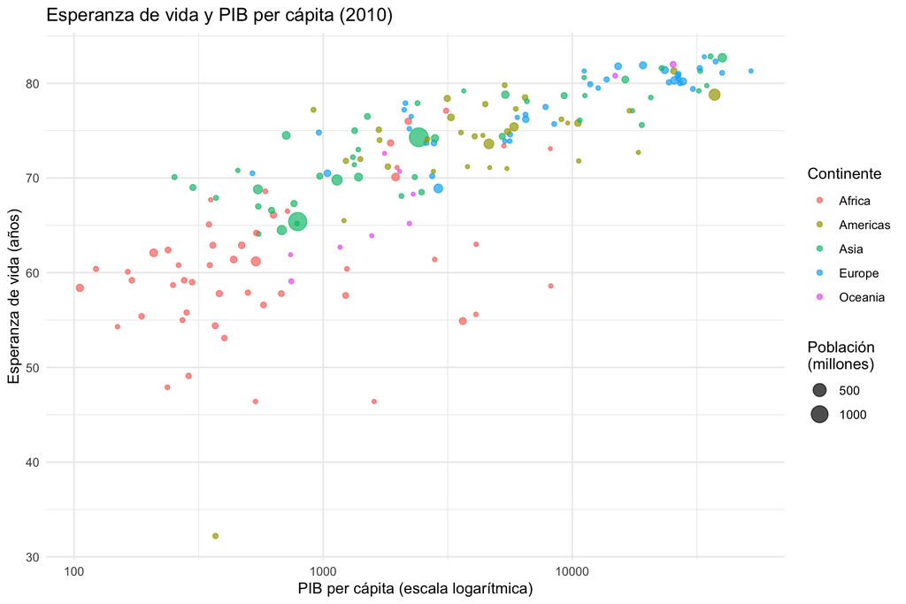

## Comparando regiones a través del tiempo

Las **facetas** dividen un gráfico en paneles según una variable. Aquí comparamos 1970 con 2010:

```r
gapminder |>
  filter(year %in% c(1970, 2010)) |>
  ggplot(aes(x = fertility, y = life_expectancy, colour = continent)) +
  geom_point(alpha = 0.6) +
  facet_wrap(~ year) +
  labs(
    title = "Convergencia global: fertilidad y esperanza de vida",
    x = "Fertilidad",
    y = "Esperanza de vida (años)",
    colour = "Continente"
  ) +
  theme_minimal()
```

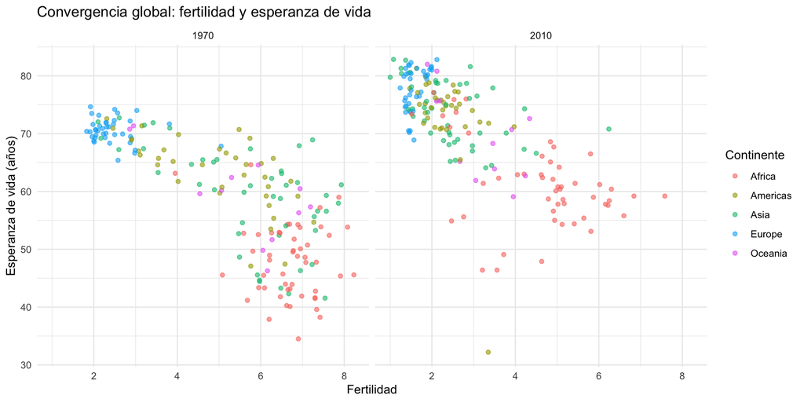

## El Caribe en contexto

```r
caribe <- c("Puerto Rico", "Cuba", "Dominican Republic",
            "Jamaica", "Trinidad and Tobago", "Haiti")

gapminder |>
  filter(country %in% caribe) |>
  ggplot(aes(x = year, y = life_expectancy, colour = country)) +
  geom_line(linewidth = 1.2) +
  geom_point(size = 2) +
  labs(
    title = "Esperanza de vida en el Caribe (1960–2016)",
    x = "Año",
    y = "Esperanza de vida (años)",
    colour = "País"
  ) +
  theme_minimal()
```

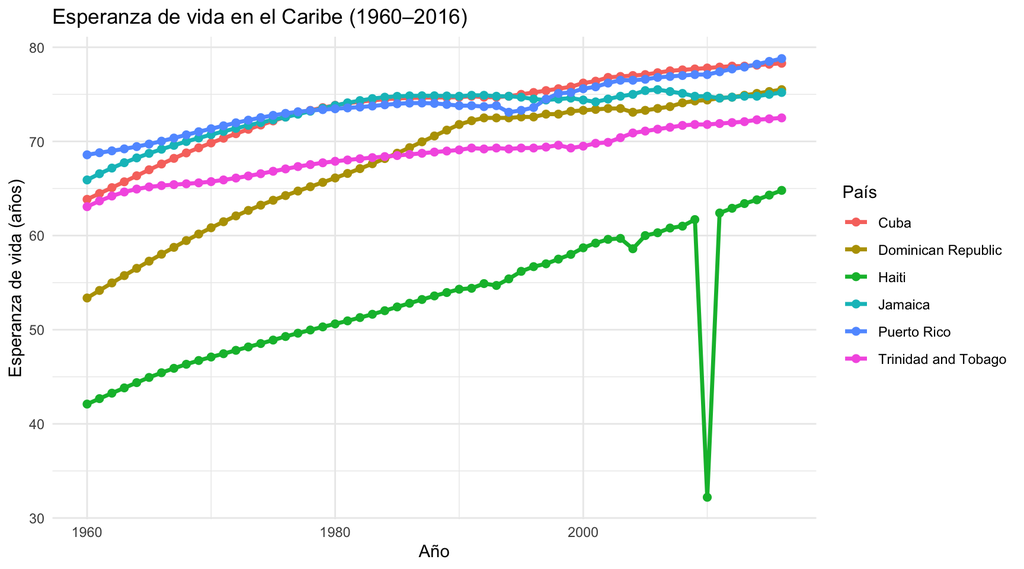

## Distribuciones por región

```r
gapminder |>
  filter(year == 2010, !is.na(gdp)) |>
  mutate(
    dolares_dia = gdp / population / 365,
    grupo = case_when(
      region %in% c("Caribbean", "Central America",
                    "South America") ~ "Latinoamérica y Caribe",
      region %in% c("Western Europe", "Northern Europe", "Southern Europe",
                    "Northern America",
                    "Australia and New Zealand") ~ "Occidente",
      continent == "Africa" ~ "África",
      TRUE ~ "Asia y otros"
    )
  ) |>
  ggplot(aes(x = reorder(grupo, dolares_dia, FUN = median),
             y = dolares_dia)) +
  geom_boxplot(aes(fill = grupo), alpha = 0.7) +
  scale_y_log10() +
  labs(
    title = "Ingreso diario per cápita por región (2010)",
    x = "", y = "Dólares por día (escala logarítmica)"
  ) +
  theme_minimal() +
  theme(legend.position = "none",
        axis.text.x = element_text(angle = 15, hjust = 1))
```

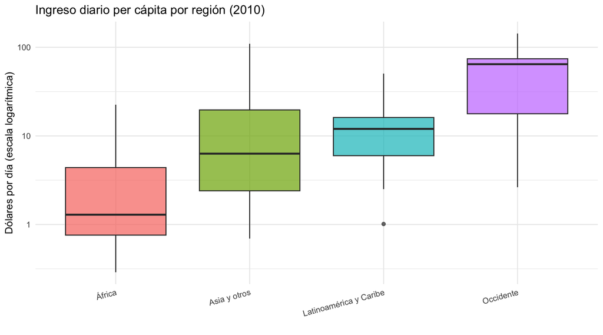

## Correlación: midiendo relaciones entre variables

La **correlación** mide la fuerza y dirección de una relación lineal. El coeficiente *r* de Pearson va de -1 a 1:

| Valor de *r* | Interpretación |
| --- | --- |
| **1** | Relación positiva perfecta |
| **0** | Sin relación lineal |
| **-1** | Relación negativa perfecta |

```r
# PIB per cápita y esperanza de vida en 2010
datos_2010 <- gapminder |>
  filter(year == 2010, !is.na(gdp)) |>
  mutate(pib_per_capita = gdp / population)

# Coeficiente de correlación
cor(datos_2010$pib_per_capita, datos_2010$life_expectancy,
    use = "complete.obs")
```

```
[1] 0.5975529
```

```r
# Prueba de significancia
cor.test(datos_2010$pib_per_capita, datos_2010$life_expectancy)
```

```
    Pearson's product-moment correlation

data:  datos_2010$pib_per_capita and datos_2010$life_expectancy
t = 9.8303, df = 174, p-value < 2.2e-16
alternative hypothesis: true correlation is not equal to 0
95 percent confidence interval:
 0.4932294 0.6849318
sample estimates:
      cor
0.5975529
```

## Visualizando la correlación

```r
datos_2010 |>
  ggplot(aes(x = pib_per_capita, y = life_expectancy)) +
  geom_point(aes(colour = continent), alpha = 0.7) +
  geom_smooth(method = "lm", se = TRUE, colour = "black",
              linetype = "dashed") +
  scale_x_log10() +
  labs(
    title = "Correlación entre PIB per cápita y esperanza de vida (2010)",
    subtitle = paste0("r = ", round(cor(datos_2010$pib_per_capita,
                                         datos_2010$life_expectancy,
                                         use = "complete.obs"), 3)),
    x = "PIB per cápita (escala logarítmica)",
    y = "Esperanza de vida (años)",
    colour = "Continente"
  ) +
  theme_minimal()
```

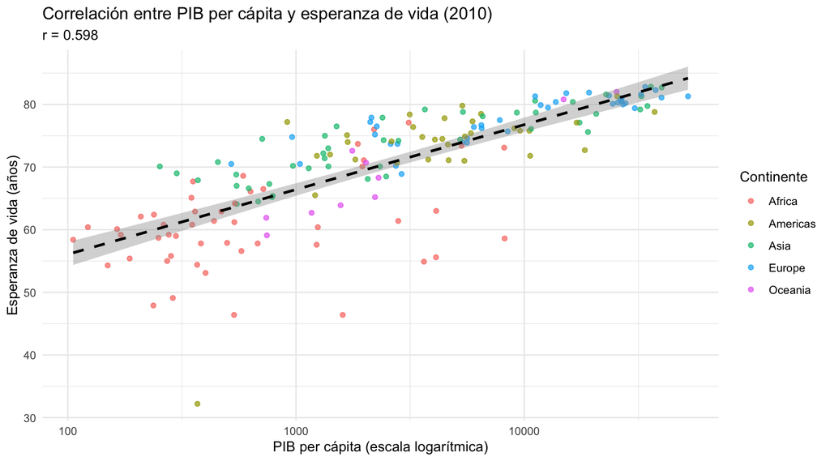

# Datos de arte: la colección del Tate

## Explorando colecciones artísticas con R

R también permite explorar datos del mundo artístico. El paquete `modeldata` incluye metadatos de obras del museo **Tate de Londres**:

```r
# install.packages("modeldata")  # Descomenten si necesitan instalar
library(modeldata)
data(tate_text)
```

```r
names(tate_text)   # ¿Qué variables describe cada obra?
```

```
[1] "id"     "artist" "title"  "medium" "year"
```

```r
head(tate_text)    # Primeras obras del catálogo
```

```
# A tibble: 6 × 5
     id artist             title                   medium                   year
  <dbl> <fct>              <chr>                   <fct>                   <dbl>
1 21926 Absalon            Proposals for a Habitat Video, monitor or proj…  1990
2 20472 Auerbach, Frank    Michael                 Etching on paper         1990
3 20474 Auerbach, Frank    Geoffrey                Etching on paper         1990
4 20473 Auerbach, Frank    Jake                    Etching on paper         1990
5 20513 Auerbach, Frank    To the Studios          Oil paint on canvas      1990
6 21389 Ayres, OBE Gillian Phaëthon                Oil paint on canvas      1990
```

```r
# Los 15 artistas con más obras en la colección
tate_text |>
  count(artist, sort = TRUE) |>
  head(15)
```

```
# A tibble: 15 × 2
   artist                        n
   <fct>                     <int>
 1 Schütte, Thomas             154
 2 Zaatari, Akram              119
 3 Beuys, Joseph                97
 4 Ferrari, León                89
 5 Kossoff, Leon                86
 6 Tillmans, Wolfgang           63
 7 Hirst, Damien                54
 8 Sorman, Steven               52
 9 Walker, John                 52
10 Baselitz, Georg              50
11 Kirkeby, Per                 50
12 Le Brun, Christopher, PRA    50
13 Winters, Terry               47
14 Doig, Peter                  41
15 McKeever, Ian                41
```

## Obras a través del tiempo

```r
tate_text |>
  filter(!is.na(year), year >= 1800) |>
  ggplot(aes(x = year)) +
  geom_histogram(binwidth = 10, fill = "steelblue", colour = "white") +
  labs(
    title = "Obras en la colección del Tate por década de creación",
    x = "Año de creación",
    y = "Cantidad de obras"
  ) +
  theme_minimal()
```

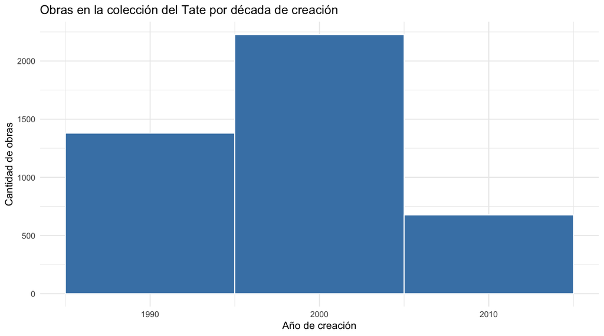

## Medios artísticos más utilizados

```r
tate_text |>
  mutate(medio_simple = word(medium, 1, 2)) |>
  count(medio_simple, sort = TRUE) |>
  head(12) |>
  ggplot(aes(x = reorder(medio_simple, n), y = n)) +
  geom_col(fill = "coral3") +
  coord_flip() +
  labs(
    title = "Medios artísticos más frecuentes en el Tate",
    x = "", y = "Cantidad de obras"
  ) +
  theme_minimal()
```

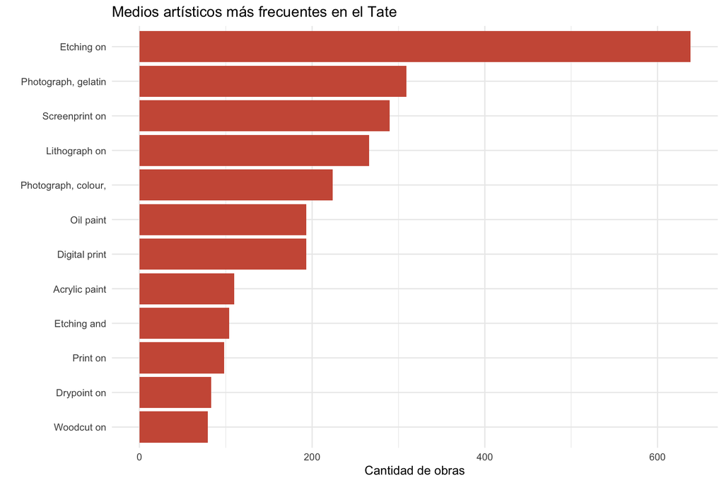

# Análisis de texto

## De las narrativas a los datos

¿Para qué sirve el análisis cuantitativo de texto?

- **Estudios literarios**: patrones léxicos, comparar estilos entre autores
- **Análisis de discurso**: vocabulario político, religioso, mediático
- **Lingüística**: bilingüismo, emociones en narrativas
- **Ciencias sociales**: contenido de medios, entrevistas, documentos históricos

## tidytext: texto como datos ordenados

El paquete `tidytext` convierte texto en una tabla donde cada fila es una palabra (*token*). Así podemos usar todas las herramientas de `tidyverse`:

```r
# install.packages(c("tidytext", "janeaustenr", "wordcloud"))
library(tidytext)
library(janeaustenr)  # Las 6 novelas de Jane Austen
```

```r
# Convertir las novelas en una tabla de palabras
austen_palabras <- austen_books() |>
  unnest_tokens(word, text)
# ↑ unnest_tokens() divide cada línea en palabras individuales

# ¿Cuántas palabras tiene cada novela?
austen_palabras |>
  count(book, sort = TRUE)
```

```
# A tibble: 6 × 2
  book                     n
  <fct>                <int>
1 Emma                160996
2 Mansfield Park      160460
3 Pride & Prejudice   122204
4 Sense & Sensibility 119957
5 Persuasion           83658
6 Northanger Abbey     77780
```

## Frecuencias de palabras (sin palabras vacías)

Las *stopwords* (palabras vacías) son artículos, preposiciones y conjunciones que no aportan contenido analítico. Al removerlas, nos quedamos con el vocabulario sustantivo:

```r
austen_freq <- austen_palabras |>
  anti_join(stop_words, by = "word") |>  # Remueve "the", "a", "is"...
  count(book, word, sort = TRUE)

# Las 10 palabras más frecuentes por novela
austen_freq |>
  group_by(book) |>
  slice_max(n, n = 10) |>
  ggplot(aes(x = reorder_within(word, n, book), y = n, fill = book)) +
  geom_col(show.legend = FALSE) +
  facet_wrap(~ book, scales = "free_y") +
  scale_x_reordered() +
  coord_flip() +
  labs(
    title = "Palabras más frecuentes en las novelas de Jane Austen",
    x = "", y = "Frecuencia"
  ) +
  theme_minimal()
```

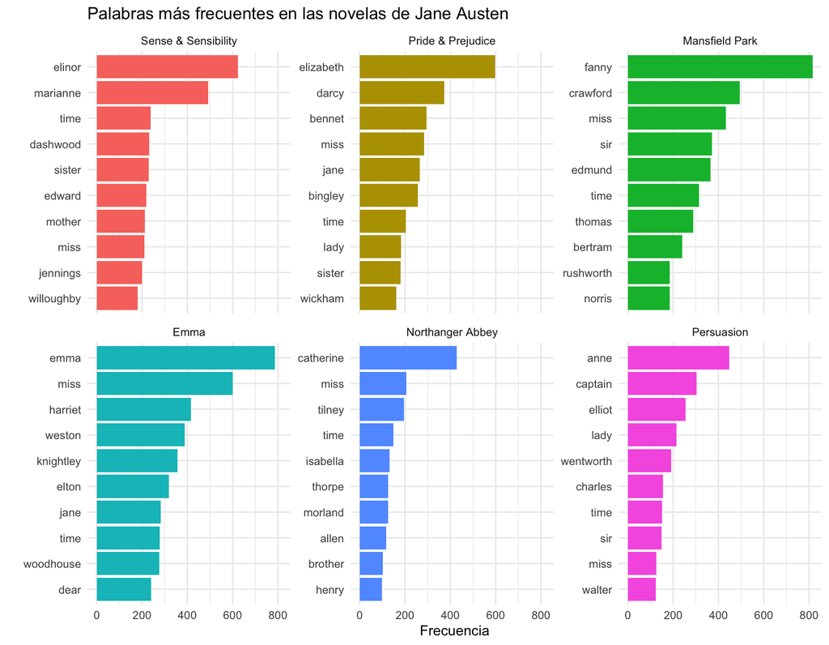

## Nubes de palabras

Una nube de palabras ofrece una representación visual rápida del vocabulario dominante:

```r
library(wordcloud)

# Nube de palabras de "Orgullo y Prejuicio"
austen_palabras |>
  filter(book == "Pride & Prejudice") |>
  anti_join(stop_words, by = "word") |>
  count(word, sort = TRUE) |>
  with(wordcloud(word, n, max.words = 80,
                 colors = brewer.pal(8, "Dark2")))
```

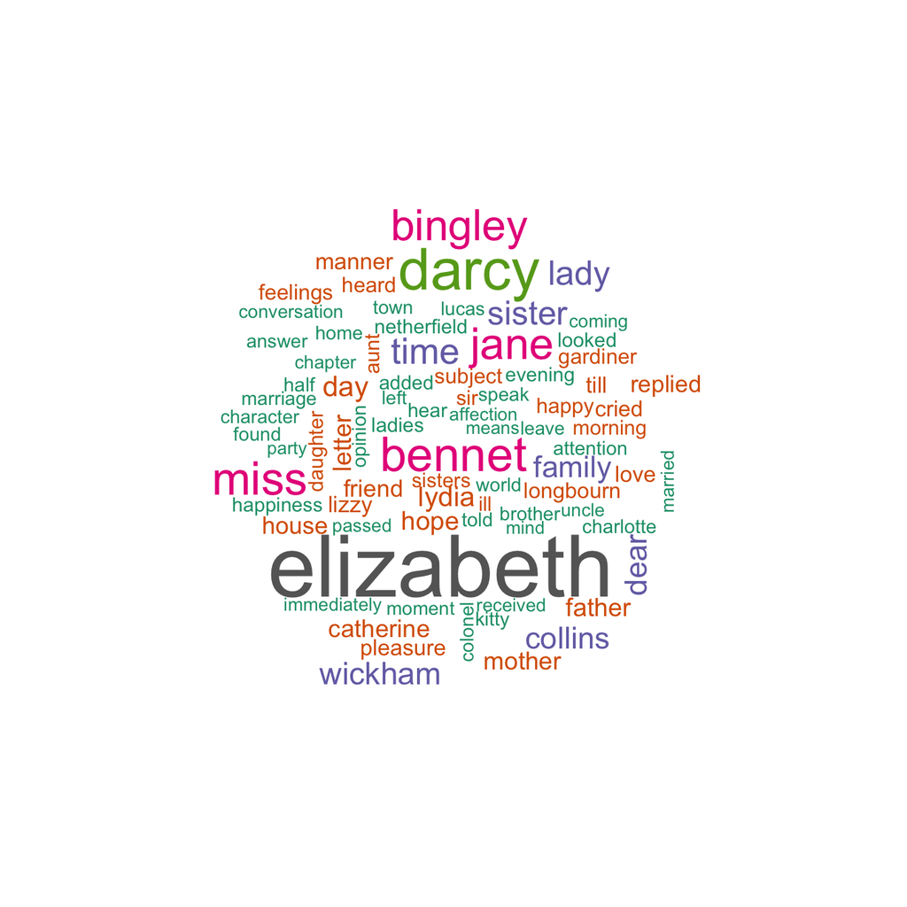

## Literatura en español: el Proyecto Gutenberg

El paquete `gutenbergr` permite acceder a más de 57,000 textos de dominio público, incluyendo centenares en español:

```r
# install.packages("gutenbergr")
library(gutenbergr)

# Buscar obras disponibles en español
obras_es <- gutenberg_works(languages = "es")
nrow(obras_es)   # ¿Cuántas obras en español hay?
```

```
[1] 912
```

```r
# Algunas obras notables
obras_es |>
  filter(grepl("Cervantes|Hostos|Dario|Burgos", author, ignore.case = TRUE)) |>
  select(gutenberg_id, title, author) |>
  head(10)
```

```
# A tibble: 6 × 3
  gutenberg_id title                                                      author
         <int> <chr>                                                      <chr>
1         2000 "Don Quijote"                                              Cerva…
2        15115 "Novelas y teatro"                                         Cerva…
3        16110 "Viage al Parnaso\nLa Numancia (Tragedia) y El Trato de A… Cerva…
4        57955 "Los entremeses"                                           Cerva…
5        61202 "Novelas ejemplares"                                       Cerva…
6        73064 "Moral social : $b apreciación de Hostos"                  Hosto…
```

## Descargando y analizando el Quijote

```r
# Descargar el Quijote (ID 2000 en Gutenberg)
quijote <- gutenberg_download(2000)

head(quijote$text, 20)  # Primeras líneas del texto
```

```
 [1] "El ingenioso hidalgo don Quijote de la Mancha"
 [2] ""
 [3] ""
 [4] ""
 [5] "por Miguel de Cervantes Saavedra"
 [6] ""
 [7] ""
 [8] ""
 [9] ""
[10] ""
[11] "El ingenioso hidalgo don Quijote de la Mancha"
[12] ""
[13] ""
[14] "  "
[15] "Tasa"
[16] ""
[17] "  "
[18] "Testimonio de las erratas"
[19] ""
[20] "  "
```

```r
nrow(quijote)            # Total de líneas
```

```
[1] 37671
```

```r
# Tokenizar: dividir el texto completo en palabras individuales
quijote_palabras <- quijote |>
  unnest_tokens(palabra, text)

nrow(quijote_palabras)  # Total de palabras en el Quijote
```

```
[1] 383636
```

```r
# Remover stopwords en español
library(stopwords)
vacias_es <- tibble(palabra = stopwords("es", source = "stopwords-iso"))

quijote_freq <- quijote_palabras |>
  anti_join(vacias_es, by = "palabra") |>  # Remueve "el", "de", "que"...
  filter(nchar(palabra) > 2) |>             # Elimina tokens muy cortos
  count(palabra, sort = TRUE)

head(quijote_freq, 20)
```

```
# A tibble: 20 × 2
   palabra        n
   <chr>      <int>
 1 don         2714
 2 quijote     2241
 3 sancho      2174
 4 señor       1065
 5 respondió   1063
 6 merced       900
 7 caballero    677
 8 dios         531
 9 señora       518
10 cosa         447
11 mundo        396
12 vida         358
13 panza        352
14 casa         335
15 digo         323
16 cura         317
17 puesto       308
18 mano         304
19 amo          298
20 caballeros   293
```

## Nube de palabras del Quijote

```r
quijote_freq |>
  with(wordcloud(palabra, n, max.words = 100,
                 colors = brewer.pal(8, "Spectral")))
```

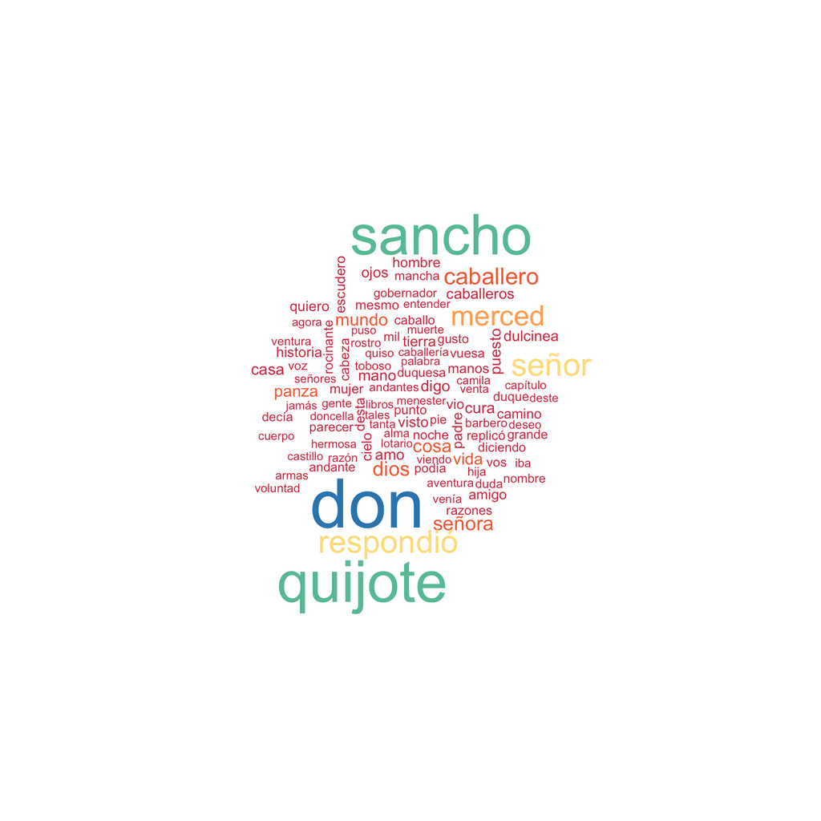

## Las 20 palabras más frecuentes del Quijote

```r
quijote_freq |>
  head(20) |>
  ggplot(aes(x = reorder(palabra, n), y = n)) +
  geom_col(fill = "darkgoldenrod3") +
  coord_flip() +
  labs(
    title = "Palabras más frecuentes en Don Quijote de la Mancha",
    subtitle = "Texto completo del Proyecto Gutenberg, sin palabras vacías",
    x = "", y = "Frecuencia"
  ) +
  theme_minimal()
```

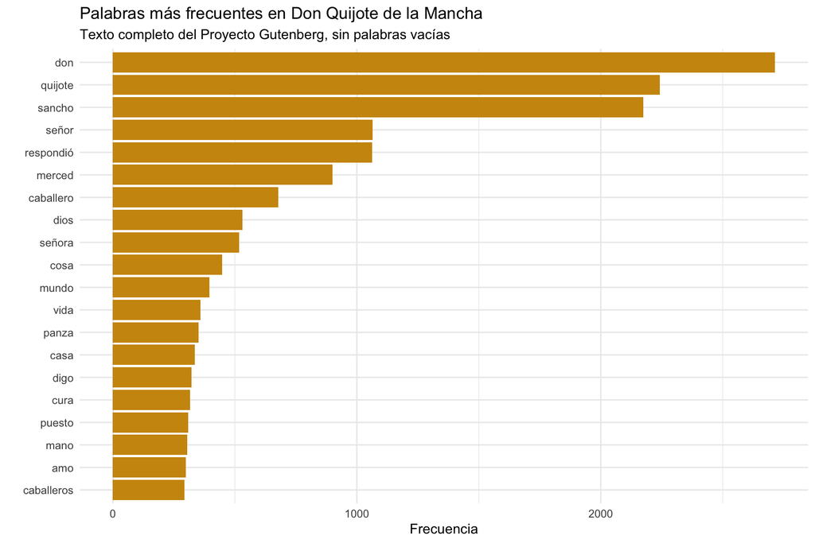

# Análisis avanzado con quanteda

## quanteda: análisis cuantitativo de corpus

`quanteda` es un paquete robusto para crear corpus, tokenizar, construir matrices documento-característica (DFM) y aplicar medidas estadísticas:

```r
# install.packages(c("quanteda", "quanteda.textstats", "quanteda.textplots"))
library(quanteda)
library(quanteda.textstats)
library(quanteda.textplots)
```

`quanteda` incluye un corpus de **discursos inaugurales presidenciales** de EEUU que sirve para explorar cambios en el lenguaje político:

```r
corp_inaug <- data_corpus_inaugural
summary(corp_inaug, 10)
```

```
Corpus consisting of 60 documents, showing 10 documents:

            Text Types Tokens Sentences Year  President   FirstName
 1789-Washington   625   1537        23 1789 Washington      George
 1793-Washington    96    147         4 1793 Washington      George
      1797-Adams   826   2577        37 1797      Adams        John
  1801-Jefferson   717   1923        41 1801  Jefferson      Thomas
  1805-Jefferson   804   2380        45 1805  Jefferson      Thomas
    1809-Madison   535   1261        21 1809    Madison       James
    1813-Madison   541   1302        33 1813    Madison       James
     1817-Monroe  1040   3677       121 1817     Monroe       James
     1821-Monroe  1259   4886       131 1821     Monroe       James
      1825-Adams  1003   3147        74 1825      Adams John Quincy
                 Party
                  none
                  none
            Federalist
 Democratic-Republican
 Democratic-Republican
 Democratic-Republican
 Democratic-Republican
 Democratic-Republican
 Democratic-Republican
 Democratic-Republican
```

## Tokenización y limpieza

La tokenización divide el texto en unidades léxicas (*tokens*). Luego limpiamos:

```r
# Tokenizar, limpiar y remover stopwords
toks_inaug <- tokens(
  corp_inaug,
  remove_punct = TRUE,     # Quita puntuación (., ;, :)
  remove_numbers = TRUE,   # Quita números
  remove_symbols = TRUE    # Quita símbolos ($, %, @)
) |>
  tokens_tolower() |>            # Todo a minúsculas
  tokens_remove(stopwords("en")) # Remueve stopwords en inglés
```

## Matriz documento-característica (DFM)

La DFM convierte texto en una tabla numérica: cada fila es un documento, cada columna un término, y cada celda cuenta cuántas veces aparece:

```r
dfm_inaug <- dfm(toks_inaug)

# Los 20 términos más frecuentes en todo el corpus
topfeatures(dfm_inaug, 20)
```

```
    people government         us        can       must       upon      great
       592        575        507        489        377        371        354
       may     states      world     nation    country      shall      every
       343        343        329        324        323        316        309
       one      peace        new      power        now     public
       274        259        256        246        238        227
```

## Nube de palabras con quanteda

```r
textplot_wordcloud(dfm_inaug, max_words = 100,
                   color = brewer.pal(8, "Set1"))
```

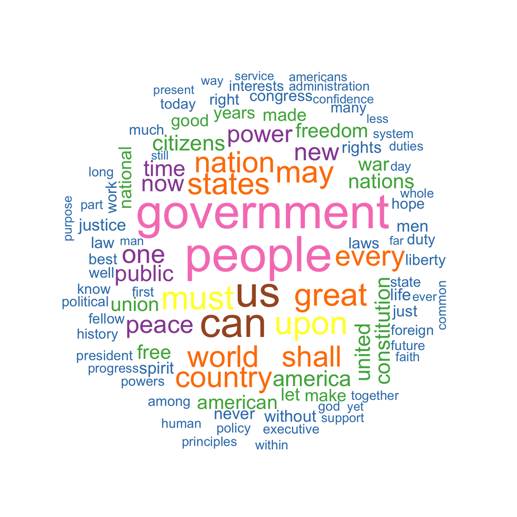

## Comparando vocabulario: *keyness*

El análisis de *keyness* identifica las palabras que **distinguen estadísticamente** a un grupo de otro. Comparemos Obama (2009) y Trump (2017):

```r
dfm_comparacion <- dfm_inaug |>
  dfm_subset(President %in% c("Obama", "Trump") &
               Year %in% c(2009, 2017))

# ¿Qué palabras distinguen a cada presidente?
k <- textstat_keyness(dfm_comparacion,
                      target = docvars(dfm_comparacion)$President == "Obama")
textplot_keyness(k, n = 15) +
  labs(title = "Vocabulario distintivo: Obama 2009 vs. Trump 2017")
```

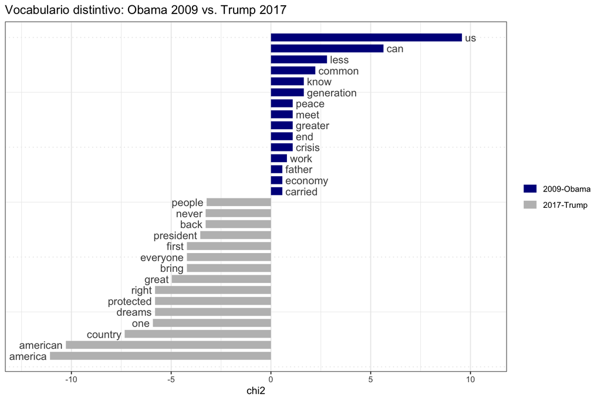

## Colocaciones: frases que van juntas

Las **colocaciones** son pares de palabras que aparecen juntas más de lo esperado por azar:

```r
# Pares de palabras frecuentes en discursos inaugurales
coll <- textstat_collocations(toks_inaug, size = 2, min_count = 5)
head(coll, 15)
```

```
          collocation count count_nested length   lambda        z
1       united states   165            0      2 7.192103 39.49267
2              let us   105            0      2 5.713775 33.34071
3     fellow citizens    79            0      2 7.080179 31.46419
4           years ago    28            0      2 6.623676 21.83995
5     american people    41            0      2 3.541725 19.54247
6  federal government    33            0      2 4.593425 19.44456
7    fellow americans    19            0      2 5.283782 19.15447
8         one another    22            0      2 4.850859 18.34433
9        almighty god    15            0      2 6.765228 17.72863
10     protect defend    11            0      2 7.052734 17.28315
11      every citizen    20            0      2 4.890585 17.24575
12         four years    26            0      2 7.683685 17.19995
13      chief justice    15            0      2 5.773613 17.17912
14        thank thank    11            0      2 6.561420 17.07919
15          men women    29            0      2 8.067501 17.02215
```

## Red de co-ocurrencias

La red muestra cómo se relacionan las palabras entre sí dentro de una ventana de contexto:

```r
# Red enfocada en los discursos de Obama
toks_obama <- tokens_subset(toks_inaug, President == "Obama")
fcmat <- fcm(toks_obama, context = "window", window = 5)
# ↑ fcm = feature co-occurrence matrix (qué palabras aparecen
#   juntas dentro de una ventana de 5 palabras)

# Seleccionar los 30 términos con mayor fuerza de co-ocurrencia
fuerza <- sort(Matrix::colSums(fcmat), decreasing = TRUE)
principales <- names(fuerza)[1:min(30, length(fuerza))]
fcm_sub <- fcm_select(fcmat, pattern = principales)

textplot_network(fcm_sub, min_freq = 3, edge_alpha = 0.5) +
  labs(title = "Red de co-ocurrencia: discursos de Obama")
```

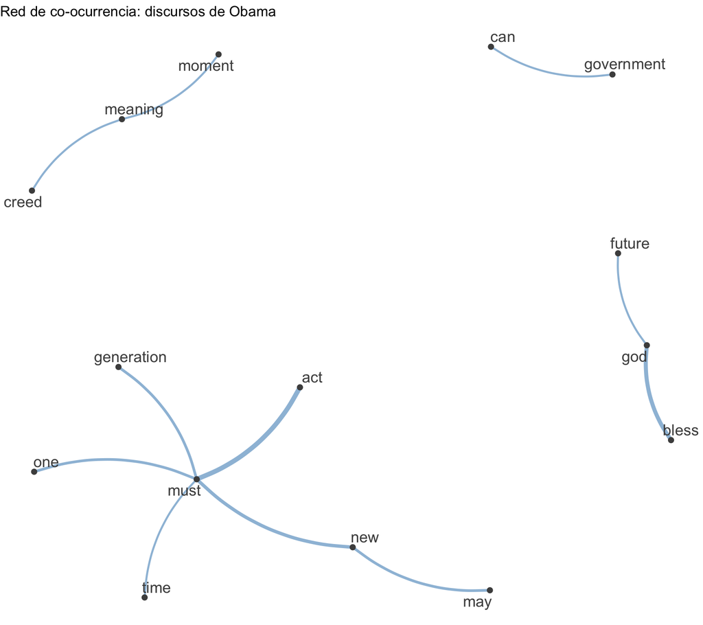

# Aplicaciones a sus investigaciones

## Posibilidades para cada disciplina

| Tema de investigación | Posible aplicación en R |
| --- | --- |
| Poesía épica caribeña | Corpus con `gutenbergr`, frecuencias léxicas, comparar tradiciones |
| Pintura y patrimonio en PR | Analizar catálogos y textos curatoriales con `tidytext` |
| Emigración y fuga de cerebros | Visualizar datos migratorios con `ggplot2`; datos censales con `tidycensus` |
| Bilingüismo y emociones | Tokenizar narrativas bilingües, comparar léxico emocional |
| Filosofía y Julia de Burgos | Corpus desde Gutenberg, temas recurrentes, diversidad léxica |

## Más aplicaciones

| Tema de investigación | Posible aplicación en R |
| --- | --- |
| Detección de *spam* en audio | Tras transcribir, analizar patrones léxicos con *keyness* |
| Partido Nacionalista de PR | Documentos históricos, discursos, redes de co-ocurrencia |
| Transformismo y cultura puertorriqueña | Cobertura mediática, representaciones textuales |
| Metodologías pedagógicas | Comparar textos curriculares, analizar sesgos en materiales |

# Recapitulando

## Qué cubrimos hoy

- **R y RStudio**: consola, objetos, funciones y vectores
- **Tidyverse**: `filter()`, `select()`, `mutate()`, `group_by()`, `summarise()`, y el *pipe* `|>`
- **Visualización**: `ggplot2` con geometrías, estéticas, facetas, escalas y temas
- **Datos de arte**: exploración de la colección del Tate
- **Análisis de texto en inglés**: `tidytext` con Jane Austen y `quanteda` con discursos inaugurales
- **Análisis de texto en español**: `gutenbergr` con el *Quijote* y *stopwords* en español

## Paquetes utilizados

Para reproducir este taller, instalen los siguientes paquetes:

```r
install.packages(c(
  "tidyverse", "dslabs", "modeldata",
  "tidytext", "janeaustenr", "gutenbergr",
  "wordcloud", "RColorBrewer", "stopwords",
  "quanteda", "quanteda.textstats", "quanteda.textplots"
))
```

## Recursos para continuar

| Recurso | Enlace |
| --- | --- |
| Intro a ciencia de datos (Irizarry, español) | leanpub.com/dslibro |
| R for Data Science (Wickham) | [r4ds.hadley.nz](https://r4ds.hadley.nz/) |
| Quanteda: guía rápida | [quanteda.io](https://quanteda.io/articles/quickstart.html) |
| Text Mining with R | [tidytextmining.com](https://www.tidytextmining.com/) |
| Proyecto Gutenberg en español | [gutenberg.org/languages/es](https://www.gutenberg.org/browse/languages/es) |
| StackOverflow | [stackoverflow.com/tagged/r](https://stackoverflow.com/questions/tagged/r) |
| Posit Cloud | [posit.cloud](https://posit.cloud/) |

## ¡Gracias!

**Prof. Rashid C.J. Marcano Rivera, Ph.D., M.S., M.A.**

Departamento de Sociología y Antropología

Facultad de Ciencias Sociales, UPR-RP

rashid.marcano [arroba] upr [punto] edu